# Machine Learning Course Project

Yilmaz Rona

January 30, 2016

# Introduction

We analyze data collected by accelerometers on the belt, forearm, arm, and dumbell of 6 participants as they performed barbell lifts correctly and incorrectly in 5 different ways as reported in [Velloso, E.; Bulling, A.; Gellersen, H.; Ugulino, W.; Fuks, H. Qualitative Activity Recognition of Weight Lifting Exercises. Proceedings of 4th International Conference in Cooperation with SIGCHI (Augmented Human ’13) . Stuttgart, Germany: ACM SIGCHI, 2013.](http://groupware.les.inf.puc-rio.br/work.jsf?p1=11201). A summary of the data collection may be found on [their website](http://groupware.les.inf.puc-rio.br/har#ixzz3yn3Qh9aj).

# Analysis

## Data Download and Preprocessing

### Load Libraries

```r
  library(caret)
  library(rpart)
  library(randomForest)
  library(rattle)
```

### Download

```r
#See Appendix titled KNITR at end for the  loaded code
knitr::read_chunk('loaddata.r')
```

```r
  data.subdirectory <- "data"
  skip.download <- FALSE #Set to true if you already have the data and are satisfied

  training.url <- "https://d396qusza40orc.cloudfront.net/predmachlearn/pml-training.csv"
  testing.url <- "https://d396qusza40orc.cloudfront.net/predmachlearn/pml-testing.csv"
  data.locations <- data.frame(url = c(training.url,testing.url),
                               file = c("training.csv","testing.csv"),
                               fullpath = c("",""),
                               row.names = c("training","testing"),
                               stringsAsFactors=FALSE)


  for (i in 1:nrow(data.locations)) {
    data.locations[i,"fullpath"] <- downloadmyurl(data.locations[i,"url"],
                                                  data.locations[i,"file"],
                                                  data.subdirectory,
                                                  inhibit.download = skip.download)
  }

  my.na.strings <-c("NA","#DIV/0!","")

  training.data <- read.csv(data.locations["training","fullpath"], na.strings=my.na.strings)
  testing.data  <- read.csv(data.locations["testing","fullpath"], na.strings=my.na.strings)
```

Training data consists of 19,622 observations of 160 variables. Testing data consists of 20 observations of 160 variables.

### Pre-Processing

```r
#See Appendix titled KNITR at end for the  loaded code
knitr::read_chunk('prepdata.r')
```

We first drop variables that are unhelpful: variables with too many NA values. We then remove variables that shouldn’t be used as predictors because any correlation would be spurious (such as timestamps).

```r
#Only keep columns where more than 25% of the data is NA
good.columns <- cols.good.NA.Percentages(training.data, min.threshold = .25, cols.to.pass = c("classe"))

#Drop columns that can only have spurious correlations
bad.patterns <- c("timestamp","window")
bad.columns <- c("X","user_name")
for (i in bad.patterns) {
  bad.columns <- c(bad.columns,grep(i,good.columns,value = TRUE))
}
#Purge any column name appearing in vector good.columns that also is in bad.columns
good.columns <- good.columns[!good.columns %in% bad.columns]

clean.training.data <- subset(training.data,select = good.columns)
```

The columns removed to avoid training on spurious correlations were:

```
## [1] "X"                    "user_name"            "raw_timestamp_part_1"
## [4] "raw_timestamp_part_2" "cvtd_timestamp"       "new_window"
## [7] "num_window"
```

```
##  [1] "roll_belt"            "pitch_belt"           "yaw_belt"
##  [4] "total_accel_belt"     "gyros_belt_x"         "gyros_belt_y"
##  [7] "gyros_belt_z"         "accel_belt_x"         "accel_belt_y"
## [10] "accel_belt_z"         "magnet_belt_x"        "magnet_belt_y"
## [13] "magnet_belt_z"        "roll_arm"             "pitch_arm"
## [16] "yaw_arm"              "total_accel_arm"      "gyros_arm_x"
## [19] "gyros_arm_y"          "gyros_arm_z"          "accel_arm_x"
## [22] "accel_arm_y"          "accel_arm_z"          "magnet_arm_x"
## [25] "magnet_arm_y"         "magnet_arm_z"         "roll_dumbbell"
## [28] "pitch_dumbbell"       "yaw_dumbbell"         "total_accel_dumbbell"
## [31] "gyros_dumbbell_x"     "gyros_dumbbell_y"     "gyros_dumbbell_z"
## [34] "accel_dumbbell_x"     "accel_dumbbell_y"     "accel_dumbbell_z"
## [37] "magnet_dumbbell_x"    "magnet_dumbbell_y"    "magnet_dumbbell_z"
## [40] "roll_forearm"         "pitch_forearm"        "yaw_forearm"
## [43] "total_accel_forearm"  "gyros_forearm_x"      "gyros_forearm_y"
## [46] "gyros_forearm_z"      "accel_forearm_x"      "accel_forearm_y"
## [49] "accel_forearm_z"      "magnet_forearm_x"     "magnet_forearm_y"
## [52] "magnet_forearm_z"
```

We now partition our training data into two groups, one used to train the machine learning system, and the other to validate it (this is distinct from the testing data set we downloaded with 20 observations we downloaded from the Internet

```r
  set.seed(10000) # For reproducibility
  training.percentage <- 2/3 #The percentage of the data that will be used for training
                              #The remainder will be used for model validation

  train.idx <- createDataPartition(clean.training.data$classe, p=training.percentage, list=FALSE)

  ml.training.data <- clean.training.data[train.idx, ]
  ml.testing.data <- clean.training.data[-train.idx, ]
```

To train the models used in machine learning, we use a data set with 13,083 observations of 53 variables. We will then validate it with 6,539 observations of 53 variables.

# Machine Learning

We will explore thre different forms of predictive modeling all based around decision trees:

1. Simplified Decision Tree Model
2. Complex Decision Tree Model
3. Random Forest Model

## A Simple Tree Model

```r
  tree.model <- train(classe ~ ., method = "rpart", data = ml.training.data)
```

A plot of the tree appears below:

[figure not shown]

```r
  fancyRpartPlot(tree.model$finalModel)
```

We can immediately see a significant problem: the tree will never classify the exercise class “D” correctly.

Testing the tree using the data segment set aside for validation results in the following confusion matrix:

```r
  prediction.Tree <- predict(tree.model, ml.testing.data, type = "raw")
  cfm.Tree <- confusionMatrix(prediction.Tree,ml.testing.data$classe)

  accuracy.Tree <- cfm.Tree$overall["Accuracy"]

  cfm.Tree
```

```
## Confusion Matrix and Statistics
##
##           Reference
## Prediction    A    B    C    D    E
##          A 1679  519  506  495  152
##          B   37  455   42  180  181
##          C  141  291  592  397  326
##          D    0    0    0    0    0
##          E    3    0    0    0  543
##
## Overall Statistics
##
##                Accuracy : 0.4999
##                  95% CI : (0.4877, 0.5121)
##     No Information Rate : 0.2844
##     P-Value [Acc > NIR] : < 2.2e-16
##
##                   Kappa : 0.347
##  Mcnemar's Test P-Value : NA
##
## Statistics by Class:
##
##                      Class: A Class: B Class: C Class: D Class: E
## Sensitivity            0.9027  0.35968  0.51930   0.0000  0.45175
## Specificity            0.6427  0.91657  0.78607   1.0000  0.99944
## Pos Pred Value         0.5010  0.50838  0.33887      NaN  0.99451
## Neg Pred Value         0.9432  0.85648  0.88564   0.8361  0.89004
## Prevalence             0.2844  0.19345  0.17434   0.1639  0.18382
## Detection Rate         0.2568  0.06958  0.09053   0.0000  0.08304
## Detection Prevalence   0.5125  0.13687  0.26717   0.0000  0.08350
## Balanced Accuracy      0.7727  0.63813  0.65268   0.5000  0.72559
```

This model is not very good. Its predictions are accurate 50% of the time. It is useful, however, in being simple enough that people can make predictions by inspection rather than needing to use a computer.

## Complex Decision Tree

```r
  tree.model2 <- rpart(classe ~ .,  data = ml.training.data, method = "class")
```

A plot of the tree appears below:

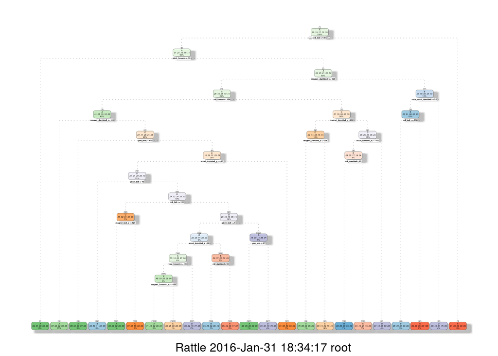

```r
  fancyRpartPlot(tree.model2)
```

With many more nodes, the tree ia not easily comprehended by a human being.

Testing the tree using the data segment set aside for validation results in the following confusion matrix:

```r
  prediction.Tree2 <- predict(tree.model2, ml.testing.data, type = "class")
  cfm.Tree2 <- confusionMatrix(prediction.Tree2,ml.testing.data$classe)
  accuracy.Tree2 <- cfm.Tree2$overall["Accuracy"]
  cfm.Tree2
```

```
## Confusion Matrix and Statistics
##
##           Reference
## Prediction    A    B    C    D    E
##          A 1704  253   22  105   38
##          B   48  695   64   39   75
##          C   59  169  922  159  158
##          D   20   75   62  668   64
##          E   29   73   70  101  867
##
## Overall Statistics
##
##                Accuracy : 0.7426
##                  95% CI : (0.7318, 0.7532)
##     No Information Rate : 0.2844
##     P-Value [Acc > NIR] : < 2.2e-16
##
##                   Kappa : 0.673
##  Mcnemar's Test P-Value : < 2.2e-16
##
## Statistics by Class:
##
##                      Class: A Class: B Class: C Class: D Class: E
## Sensitivity            0.9161   0.5494   0.8088   0.6231   0.7213
## Specificity            0.9107   0.9571   0.8991   0.9596   0.9488
## Pos Pred Value         0.8030   0.7546   0.6285   0.7514   0.7605
## Neg Pred Value         0.9647   0.8985   0.9570   0.9285   0.9380
## Prevalence             0.2844   0.1935   0.1743   0.1639   0.1838
## Detection Rate         0.2606   0.1063   0.1410   0.1022   0.1326
## Detection Prevalence   0.3245   0.1408   0.2243   0.1360   0.1743
## Balanced Accuracy      0.9134   0.7533   0.8539   0.7914   0.8351
```

## Random Forest

A random forest is an ensemble of simple decision trees, built on subsets of the data. Each decision tree will provide an independent prediction given a set of predictors. In theory, most of the decision trees will provide the correct answer, and so the most common prediction produced by the individual trees is used as the prediction of the ensemble.

```r
  forest.model <- randomForest(classe ~ . , data=ml.training.data)
  prediction.forest <- predict(forest.model,ml.testing.data, type = "class")
  cfm.Forest <- confusionMatrix(prediction.forest,ml.testing.data$classe)

  accuracy.Forest <- cfm.Forest$overall["Accuracy"]
  cfm.Forest
```

```
## Confusion Matrix and Statistics
##
##           Reference
## Prediction    A    B    C    D    E
##          A 1859    4    0    0    0
##          B    0 1261    6    0    0
##          C    0    0 1133   16    0
##          D    1    0    1 1056    2
##          E    0    0    0    0 1200
##
## Overall Statistics
##
##                Accuracy : 0.9954
##                  95% CI : (0.9935, 0.9969)
##     No Information Rate : 0.2844
##     P-Value [Acc > NIR] : < 2.2e-16
##
##                   Kappa : 0.9942
##  Mcnemar's Test P-Value : NA
##
## Statistics by Class:
##
##                      Class: A Class: B Class: C Class: D Class: E
## Sensitivity            0.9995   0.9968   0.9939   0.9851   0.9983
## Specificity            0.9991   0.9989   0.9970   0.9993   1.0000
## Pos Pred Value         0.9979   0.9953   0.9861   0.9962   1.0000
## Neg Pred Value         0.9998   0.9992   0.9987   0.9971   0.9996
## Prevalence             0.2844   0.1935   0.1743   0.1639   0.1838
## Detection Rate         0.2843   0.1928   0.1733   0.1615   0.1835
## Detection Prevalence   0.2849   0.1938   0.1757   0.1621   0.1835
## Balanced Accuracy      0.9993   0.9979   0.9954   0.9922   0.9992
```

The result is outstanding!!! In terms of specificity and sensitivity, the random forest provides nearly perfect predictions. Its predictive accuracy is 99.5%. However, the inner workings of the model are obscured, and as a result a person cannot easily identify which predictor values constitute good performance of the exercise, and which combinations represent which common mistakes in the physical exercise.

However, for our needs, making predictions for our test set, it is precisely what we need.

# Predictions

```r
  prediction.test.data <- predict(forest.model,testing.data, type = "class")

  prediction.test.data
```

```
##  1  2  3  4  5  6  7  8  9 10 11 12 13 14 15 16 17 18 19 20
##  B  A  B  A  A  E  D  B  A  A  B  C  B  A  E  E  A  B  B  B
## Levels: A B C D E
```

# Appendix 1: KNITR

## Data Downloading

From loaddata.r

```r
prep.data.directory <- function(data.path) {
  if (!file.exists(data.path)) {
    dir.create(data.path)
  }
}
```

```r
downloadmyurl <- function(url.string, target.name, data.path, inhibit.download=FALSE) {
  prep.data.directory(data.path)
  target.path <- paste(data.path, target.name, sep = "/")
  if (!inhibit.download) {
    download.file(url.string, destfile = target.path, method="curl")
  }

  return (target.path)
}
```

## Data Preprocessing

From prepdata.r

```r
NA.Percentage <- function(x) {
  #Returns the percentage of observations in a vector that are NA
  sum(is.na(x))/length(x)
}

cols.good.NA.Percentages <- function(x, min.threshold = 0.10, cols.to.pass =c()) {
  #Is passed:
  #   a data frame,
  #   a minimum threshold below which columns are excluded, and
  #   a vector of columns to allow even if they don't meet the threshold.
  #Returns a vector of columns that have fewer NA's than the threshold

  NA.percentages <- data.frame(sapply(x,NA.Percentage))
  colnames( NA.percentages ) <- "ratio"

  good.cols <- subset(NA.percentages , ratio < min.threshold)

  if (length(cols.to.pass) > 0) {
    #First we find the rows associated with the columns we will pass
    #(ignoring columns that don't exist)
    pass.cols <- subset(NA.percentages, row.names(NA.percentages) %in% cols.to.pass)

    #We then identify any of the rows that didn't make the cut above
    candidate.cols <-rownames(pass.cols)
    missing.candidates <- candidate.cols[!candidate.cols %in% rownames(good.cols)]

    #Finally we concatenate the two sets
    old.row.names <- rownames(good.cols)
    good.cols <- rbind(good.cols,pass.cols[missing.candidates,])

    rownames(good.cols) <- c(old.row.names,missing.candidates)

  }

  return(rownames(good.cols))
}
```